# Storytelling Data Visualization on Exchange Rates

The dataset we'll use describes Euro daily exchange rates between 1999 and 2021. The euro (symbolized with €) is the official currency in most of the countries of the European Union.

If the exchange rate of the euro to the US dollar is 1.5, you get 1.5 US dollars if you pay 1.0 euro (one euro has more value than one US dollar at this exchange rate).

Daria Chemkaeva put together the data set and made it available on Kaggle — the data source is the European Central Bank. Note that the dataset gets regular updates — we downloaded it on January 2021.

```python
import pandas as pd
import numpy as np

exchange_rates = pd.read_csv("euro-daily-hist_1999_2020.csv")
exchange_rates.info()
```

```
<class 'pandas.core.frame.DataFrame'>
RangeIndex: 5699 entries, 0 to 5698
Data columns (total 41 columns):
 #   Column                    Non-Null Count  Dtype
---  ------                    --------------  -----
 0   Period\Unit:              5699 non-null   object
 1   [Australian dollar ]      5699 non-null   object
 2   [Bulgarian lev ]          5297 non-null   object
 3   [Brazilian real ]         5431 non-null   object
 4   [Canadian dollar ]        5699 non-null   object
 5   [Swiss franc ]            5699 non-null   object
 6   [Chinese yuan renminbi ]  5431 non-null   object
 7   [Cypriot pound ]          2346 non-null   object
 8   [Czech koruna ]           5699 non-null   object
 9   [Danish krone ]           5699 non-null   object
```

[output cut: 33 more lines]

## Data Cleaning

Before we start creating data visualizations, we'll need to do a bit of data cleaning. To leave you more time to practice your data visualization skills, we'll provide you with most of the code necessary for data cleaning.

Our focus in the guided part of the project will be on the exchange rate between the euro and the American dollar. If you want to explore a different currency after finishing the guided part, the code we use for cleaning will come in handy.

Below, we do the following:

We rename the `[US dollar]` and `Period\Unit:` columns to something easier to type — `US_dollar` and `Time`.

- We change the Time column to a datetime data type.
- We sort the values by Time in ascending order.
- We reset the index (and drop the initial index).

```python
exchange_rates.rename(columns={'[US dollar ]': 'US_dollar',
                               'Period\\Unit:': 'Time'},
                      inplace=True)
exchange_rates['Time'] = pd.to_datetime(exchange_rates['Time'])
exchange_rates.sort_values('Time', inplace=True)
exchange_rates.reset_index(drop=True, inplace=True)
```

```python
euro_to_dollar = exchange_rates[["US_dollar", "Time"]].copy()
euro_to_dollar["US_dollar"].value_counts()
```

```
-         62
1.2276     9
1.1215     8
1.1305     7
1.3373     6
          ..
1.2243     1
1.3097     1
1.1122     1
0.8927     1
1.3503     1
Name: US_dollar, Length: 3528, dtype: int64
```

Run the `Series.value_counts()` method on the `US_dollar` column, and we notice that there a re some rows have `-` character. We will drow all the rows taht have the character `-` in the `US_dollar` collumn.

```python
dollar_bool = euro_to_dollar["US_dollar"] != '-'
euro_to_dollar = euro_to_dollar[dollar_bool]
```

We convert the `US_dollar` column to a `float` data type

```python
euro_to_dollar["US_dollar"] = euro_to_dollar["US_dollar"].astype('float')
euro_to_dollar.info()
```

```
<class 'pandas.core.frame.DataFrame'>
Int64Index: 5637 entries, 0 to 5698
Data columns (total 2 columns):
 #   Column     Non-Null Count  Dtype
---  ------     --------------  -----
 0   US_dollar  5637 non-null   float64
 1   Time       5637 non-null   datetime64[ns]
dtypes: datetime64[ns](1), float64(1)
memory usage: 132.1 KB
```

## Rolliing Mean

Now that we're finished cleaning the data, we'll generate a line plot to visualize the evolution of the euro-dollar exchange rate.

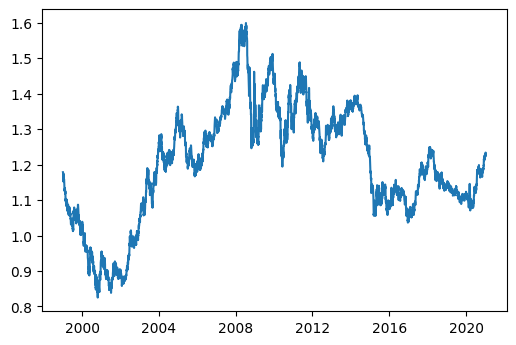

```python
import matplotlib.pyplot as plt
%matplotlib inline

plt.plot(euro_to_dollar['Time'],
         euro_to_dollar['US_dollar'])
plt.show()
```

If we look at the line's shape, we see many small wiggles — rather than seeing a smooth line. The wiggles, however, have meaning: : they are the visual representation of the daily variation in the exchange rate. The rate goes up and down, up and down again, day to day. The rate only shows clear upward or downward trends in the longer run (months or years).

we want to hide it and show only the long-term trends, we can use the rolling mean (also known as the moving average). We will do a rolling mean of 30 days

```python
euro_to_dollar["rolling_means"] = euro_to_dollar["US_dollar"].rolling(30).mean()
euro_to_dollar
```

|  | US_dollar | Time | rolling_means |
| --- | --- | --- | --- |
| 0 | 1.1789 | 1999-01-04 | NaN |
| 1 | 1.1790 | 1999-01-05 | NaN |
| 2 | 1.1743 | 1999-01-06 | NaN |
| 3 | 1.1632 | 1999-01-07 | NaN |
| 4 | 1.1659 | 1999-01-08 | NaN |
| ... | ... | ... | ... |
| 5694 | 1.2296 | 2021-01-04 | 1.211170 |
| 5695 | 1.2271 | 2021-01-05 | 1.212530 |
| 5696 | 1.2338 | 2021-01-06 | 1.213987 |
| 5697 | 1.2276 | 2021-01-07 | 1.215357 |
| 5698 | 1.2250 | 2021-01-08 | 1.216557 |

5637 rows × 3 columns

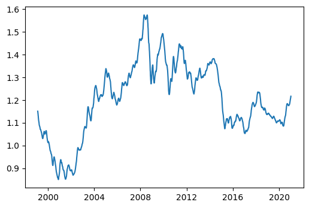

```python
plt.plot(euro_to_dollar['Time'],
         euro_to_dollar['rolling_means'])
plt.show()
```

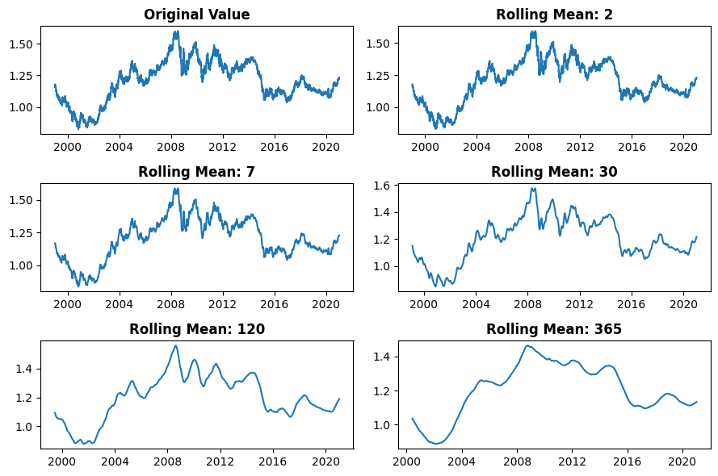

```python
plt.figure(figsize=(9,6))

# orginal plot
plt.subplot(3, 2, 1)
plt.plot(euro_to_dollar['Time'],
         euro_to_dollar['US_dollar'])
plt.title("Original Value", weight='bold')
# rolling mean

for i, rolling_mean in zip([2,3,4,5,6], [2,7,30,120,365]):
    plt.subplot(3, 2, i)
    plt.plot(euro_to_dollar['Time'],
         euro_to_dollar['US_dollar'].rolling(rolling_mean).mean())
    plt.title("Rolling Mean: "+ str(rolling_mean), weight='bold')
    plt.tight_layout()
```

## Coming up with an idea

Here are a few story ideas for our data:

- We show how the euro-dollar rate has changed during the coronavirus pandemic. We can show the 2020 data and the 2016-2019 data as a baseline. We can use a line plot.
- We show how the euro-dollar rate changed during the 2007-2008 financial crisis. We can also show the data for 2006 and 2009 for comparison. We can use a line plot.
- We show comparatively how the euro-dollar rate changed under the last three US presidents (George W. Bush (2001-2009), Barack Obama (2009-2017), and Donald Trump (2017-2021)). We can use a line plot.

### Corona Virus pandemic

```python
before_covid = euro_to_dollar[ (euro_to_dollar["Time"].dt.year <= 2019) & (euro_to_dollar["Time"].dt.year >= 2016) ]
year_2020 = euro_to_dollar[euro_to_dollar["Time"].dt.year >= 2020]
print(before_covid)
print(year_2020)
```

```
      US_dollar       Time  rolling_means
4415     1.0898 2016-01-04       1.081743
4416     1.0746 2016-01-05       1.081937
4417     1.0742 2016-01-06       1.082307
4418     1.0868 2016-01-07       1.083030
4419     1.0861 2016-01-08       1.083947
...         ...        ...            ...
5432     1.1075 2019-12-23       1.106783
5433     1.1080 2019-12-24       1.107000
5434     1.1153 2019-12-27       1.107490
5435     1.1189 2019-12-30       1.108130
5436     1.1234 2019-12-31       1.108797

[1022 rows x 3 columns]
      US_dollar       Time  rolling_means
5437     1.1193 2020-01-02       1.109237
5438     1.1147 2020-01-03       1.109470
5439     1.1194 2020-01-06       1.109920
5440     1.1172 2020-01-07       1.110190
5441     1.1115 2020-01-08       1.110380
...         ...        ...            ...
5694     1.2296 2021-01-04       1.211170
5695     1.2271 2021-01-05       1.212530
5696     1.2338 2021-01-06       1.213987
5697     1.2276 2021-01-07       1.215357
5698     1.2250 2021-01-08       1.216557

[262 rows x 3 columns]
```

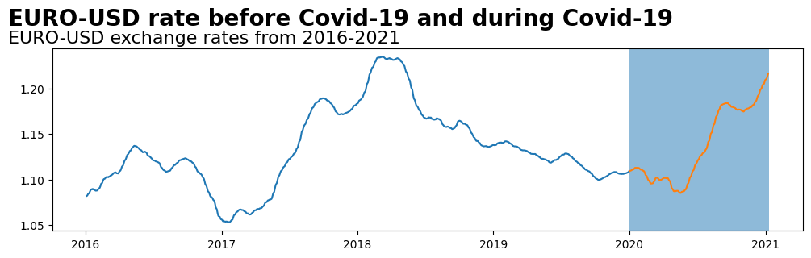

```python
fig, ax = plt.subplots(figsize =(12,3))
#add plot
ax.plot(before_covid["Time"], before_covid["rolling_means"])
ax.plot(year_2020["Time"], year_2020["rolling_means"])
#add highlight
plt.axvspan(xmin=737425.0, xmax=737800.0, alpha=0.5, lw=0)
#add title
ax.text(735756.0, 1.27, 'EURO-USD rate before Covid-19 and during Covid-19',
         fontsize=20, weight='bold')
ax.text(735756.0, 1.25, '''EURO-USD exchange rates from 2016-2021''',
        fontsize=16)

plt.show()
```

### 2007-2008 Financial Crisis

```python
not_financial_crisis = euro_to_dollar[(euro_to_dollar['Time'].dt.year >= 2006
                   ) & (euro_to_dollar['Time'].dt.year <= 2009)]
financial_crisis = euro_to_dollar[(euro_to_dollar.Time.dt.year >= 2007
                   ) & (euro_to_dollar.Time.dt.year <= 2008)]

print(financial_crisis)
print(not_financial_crisis)
```

```
      US_dollar       Time  rolling_means
2086     1.3270 2007-01-02       1.314257
2087     1.3231 2007-01-03       1.315780
2088     1.3106 2007-01-04       1.316663
2089     1.3084 2007-01-05       1.317563
2090     1.3006 2007-01-08       1.317963
...         ...        ...            ...
2601     1.3978 2008-12-23       1.303717
2602     1.4005 2008-12-24       1.308633
2605     1.4270 2008-12-29       1.314450
2606     1.4098 2008-12-30       1.319193
2607     1.3917 2008-12-31       1.323383

[511 rows x 3 columns]
      US_dollar       Time  rolling_means
1825     1.1826 2006-01-02       1.183087
1826     1.1875 2006-01-03       1.183300
1827     1.2083 2006-01-04       1.184573
1828     1.2088 2006-01-05       1.185613
1829     1.2093 2006-01-06       1.186647
...         ...        ...            ...
2863     1.4398 2009-12-24       1.477640
2865     1.4405 2009-12-28       1.476097
2866     1.4433 2009-12-29       1.474323
2867     1.4338 2009-12-30       1.472533
2868     1.4406 2009-12-31       1.470697

[1022 rows x 3 columns]
```

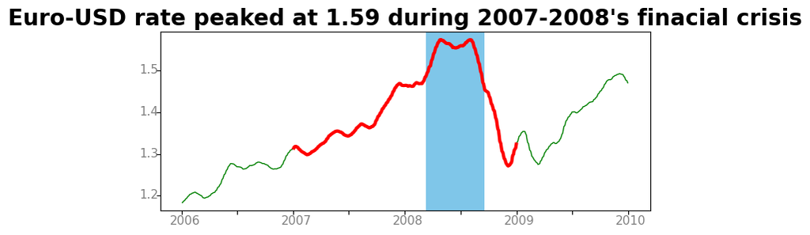

```python
#using the OO apporach (use this approach if we want to hay the subplots divide equally)
fig, ax = plt.subplots(figsize = (8,3))

#add not_financial_crisis
ax.plot(not_financial_crisis["Time"], not_financial_crisis["rolling_means"], color = "green", linewidth = 1 )
#add the financial crisis
ax.plot(financial_crisis["Time"], financial_crisis["rolling_means"], color = "red", linewidth = 3)

#add the style
plt.style.use('fivethirtyeight')
#add the title
ax.set_title("Euro-USD rate peaked at 1.59 during 2007-2008's finacial crisis", weight = "bold")

#remove tick label
ax.set_xticklabels([])
ax.set_yticklabels([])

# add custom tick labels
years = ["2006","", "2007","", "2008","", "2009","", "2010"]
rates = [1.2,1.3, 1.4, 1.5]

# add x and y
#ax.set_xticklabels(years)


#ax.set_ylim(1.1, 1.6)
#ax.set_yticks(rates)
#ax.set_yticklabels(rates)

#Or
x = 732272.0
for year in ['2006', '2007', '2008', '2009', '2010']:
    ax.text(x, 1.13, year, alpha=0.5, fontsize=11)
    x += 365

y = 1.193
for rate in ['1.2', '1.3', '1.4', '1.5']:
    ax.text(732172.0, y, rate, alpha=0.5, fontsize=11)
    y += 0.1
#add highlight
plt.axvspan(xmin=733112.0, xmax=733302.0, alpha=0.5, lw=0)

plt.show()
```

### US Presidents

```python
bush_obama_trump = euro_to_dollar[(euro_to_dollar['Time'].dt.year >= 2001) & (euro_to_dollar['Time'].dt.year < 2021)]
bush = bush_obama_trump[(bush_obama_trump["Time"].dt.year < 2009)]
obama = bush_obama_trump[(bush_obama_trump["Time"].dt.year >= 2009
                   ) & (bush_obama_trump["Time"].dt.year < 2017)]
trump = bush_obama_trump[(bush_obama_trump["Time"].dt.year >= 2017
                   ) & (bush_obama_trump["Time"].dt.year <= 2021)]


print(trump)
print(obama)
print(bush)
```

```
      US_dollar       Time  rolling_means
4672     1.0465 2017-01-02       1.055517
4673     1.0385 2017-01-03       1.054697
4674     1.0437 2017-01-04       1.054097
4675     1.0501 2017-01-05       1.053760
4676     1.0589 2017-01-06       1.053897
...         ...        ...            ...
5689     1.2193 2020-12-24       1.204173
5690     1.2219 2020-12-28       1.205520
5691     1.2259 2020-12-29       1.206950
5692     1.2281 2020-12-30       1.208280
5693     1.2271 2020-12-31       1.209623

[1022 rows x 3 columns]
      US_dollar       Time  rolling_means
```

[output cut: 27 more lines]

[figure not shown]

```python
### Adding the subplots, because we dont want our axes to layout equall, this is how we should approach
plt.figure(figsize=(12, 6)) # add the canvas

#manually add the axes
ax1 = plt.subplot(2,3,1)
ax2 = plt.subplot(2,3,2)
ax3 = plt.subplot(2,3,3)
ax4 = plt.subplot(2,1,2)
axes = [ax1, ax2, ax3, ax4]

# add Bush
ax1.plot(bush["Time"], bush["rolling_means"], color = "purple", linewidth = 3)
#add Obama
ax2.plot(obama["Time"], obama["rolling_means"], color = "orange", linewidth = 3 )
# add Trump
ax3.plot(trump["Time"], trump["rolling_means"], color = "blue", linewidth = 3)

# remove all tick labels
for ax in axes:
    ax.set_xticklabels([])
    ax.set_yticklabels([])
#set y ticks and y labels for all axes
rates = [1.0, 1.2, 1.4, 1.6]
for ax in axes:
    ax.set_ylim(0.8, 1.7)
    ax.set_yticks(rates)
    ax.set_yticklabels(rates, alpha = 0.4)

#add Bush's years
bushYears = ["", "2001", "", "2003", "", "2005", "", "2007", "", "2009"]
ax1.set_xticklabels(bushYears, alpha = 0.3)
#add Obama's years
obamaYears = ["", "2009", "", "2011", "", "2013", "", "2015", "", "2017"]
ax2.set_xticklabels(obamaYears, alpha = 0.3)
#add Trump's years
trumpYears = ["2017", "", "2018", "", "2019", "", "2020", "", "2021"]
ax3.set_xticklabels(trumpYears, alpha = 0.3)
#Add graphs' titles
ax1.set_title("Bush \n 2007-2009", color="purple")
ax2.set_title("Obama \n 2009-2017", color = "orange")
ax3.set_title("Trump \n 2017-2018", color = "blue")
#add title and subtitle for the figure
ax1.text(730016.0, 2.35, 'EURO-USD rate averaged 1.22 under the last three US presidents',
         fontsize=20, weight='bold')
ax1.text(730016.0, 2.14, '''EURO-USD exchange rates under George W. Bush (2001 - 2009), Barack Obama (2009-2017),
and Donald Trump (2017-2021)''',
        fontsize=16)
#cumulative graph
ax4.plot(bush["Time"], bush["rolling_means"], color = "purple", linewidth = 3)
ax4.plot(obama["Time"], obama["rolling_means"], color = "orange", linewidth = 3)
ax4.plot(trump["Time"], trump["rolling_means"], color = "blue", linewidth = 3)
ax4.xaxis.grid(alpha = 0.5)

plt.show()
```